# SOMBrero GSOC Tests

#### **Clustering Interpretations**

`SOMBrero` provides many different types of plots to understand the SOM model better.

**Plots showing variation of row/column variables amongs clusters**

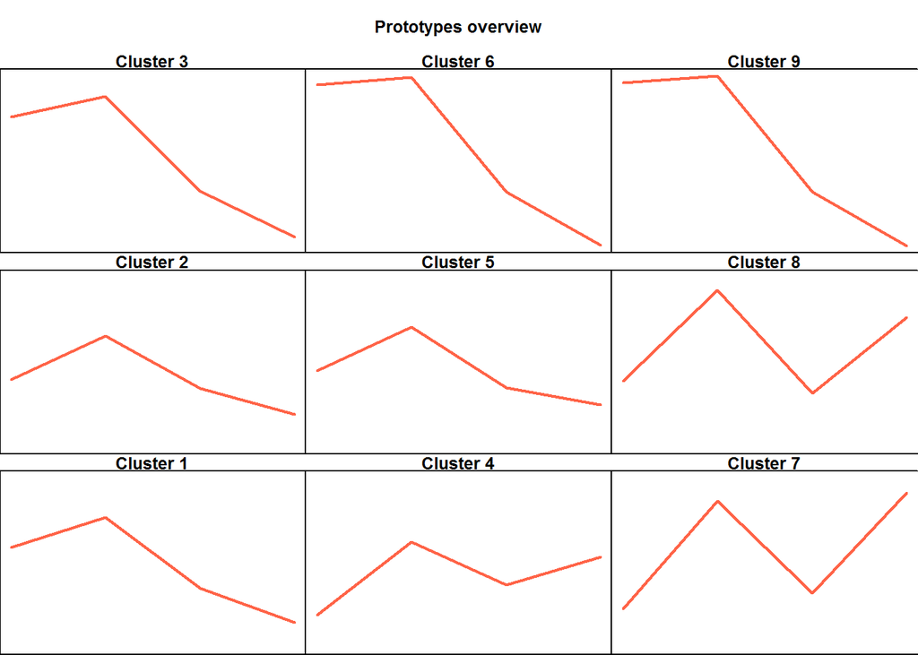

```r
plot(korresp.som, what="prototypes", type="lines", view="r", print.title=TRUE)
```

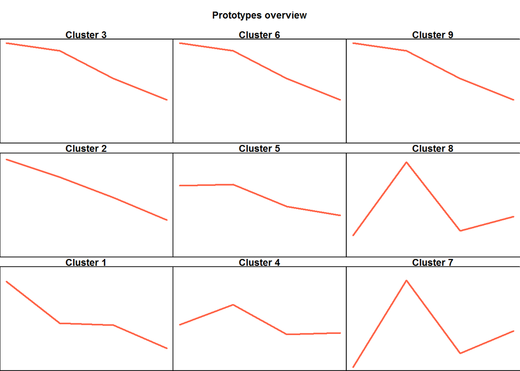

```r
plot(korresp.som, what="prototypes", type="lines", view="c", print.title=TRUE)
```

Distribution of Males having Black hairs in various clusters :

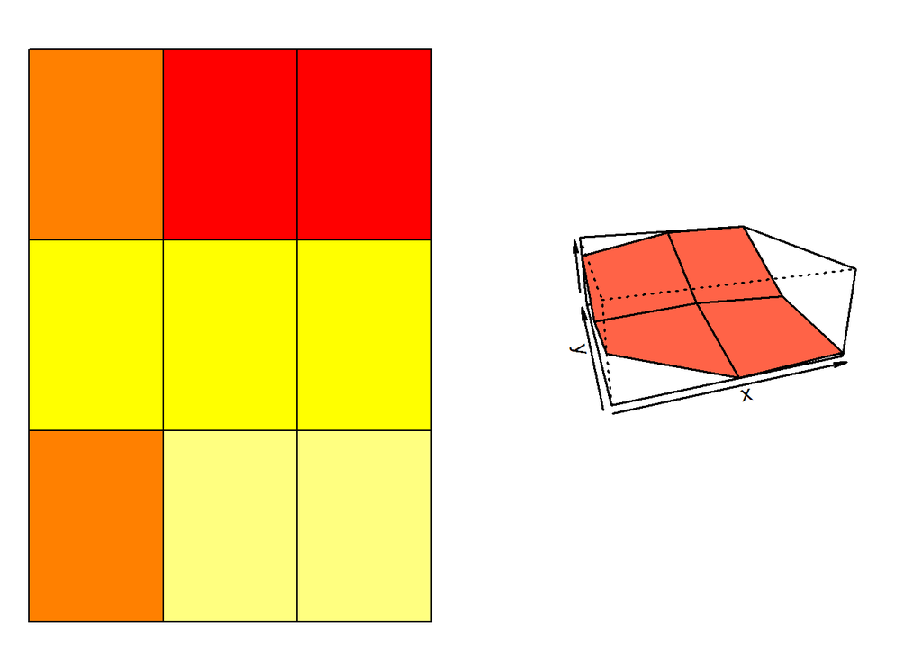

```r
par(mfrow=c(1,2))
plot(korresp.som, what="prototypes", type="color", variable="HairBlack")
plot(korresp.som, what="prototypes", type="3d", variable="HairBlack")
```

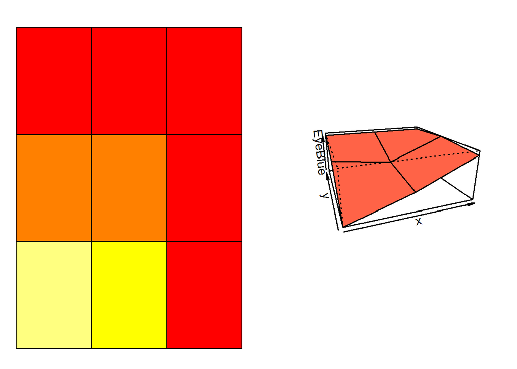

```r
par(mfrow=c(1,2))
plot(korresp.som, what="prototypes", type="color", variable=2, view="c")
plot(korresp.som, what="prototypes", type="3d", variable=2, view="c")
```

**Plots showing distances amongst various clusters.**

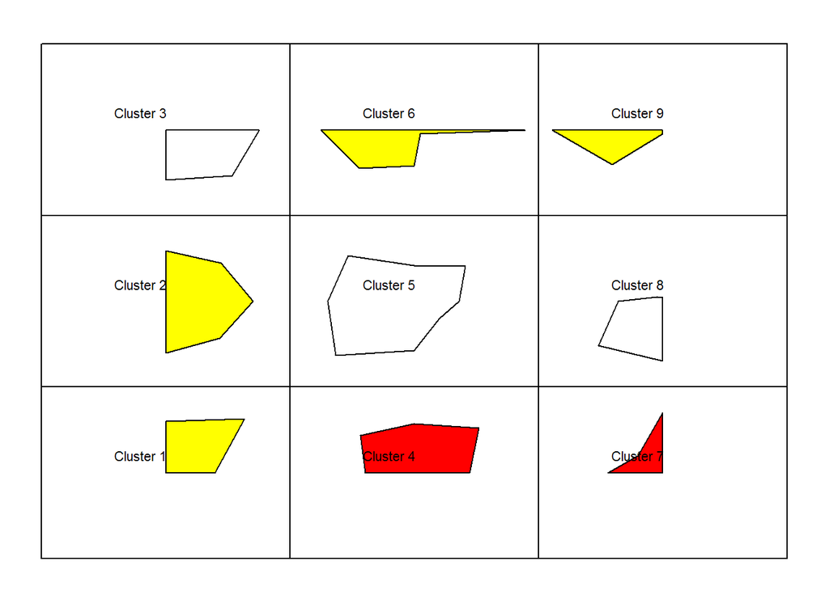

```r
plot(korresp.som, what="prototypes", type="poly.dist", print.title=TRUE)
```

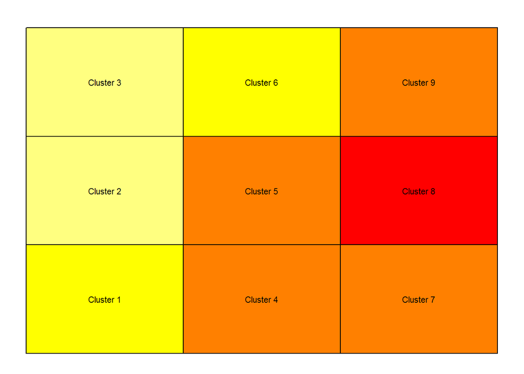

```r
plot(korresp.som, what="prototypes", type="umatrix", print.title=TRUE)
```

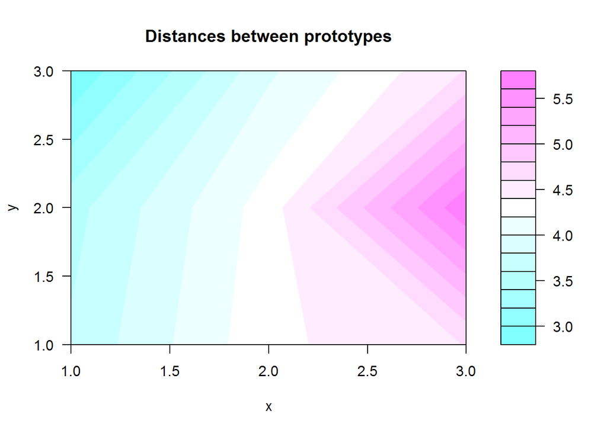

```r
plot(korresp.som, what="prototypes", type="smooth.dist", print.title=TRUE)
```

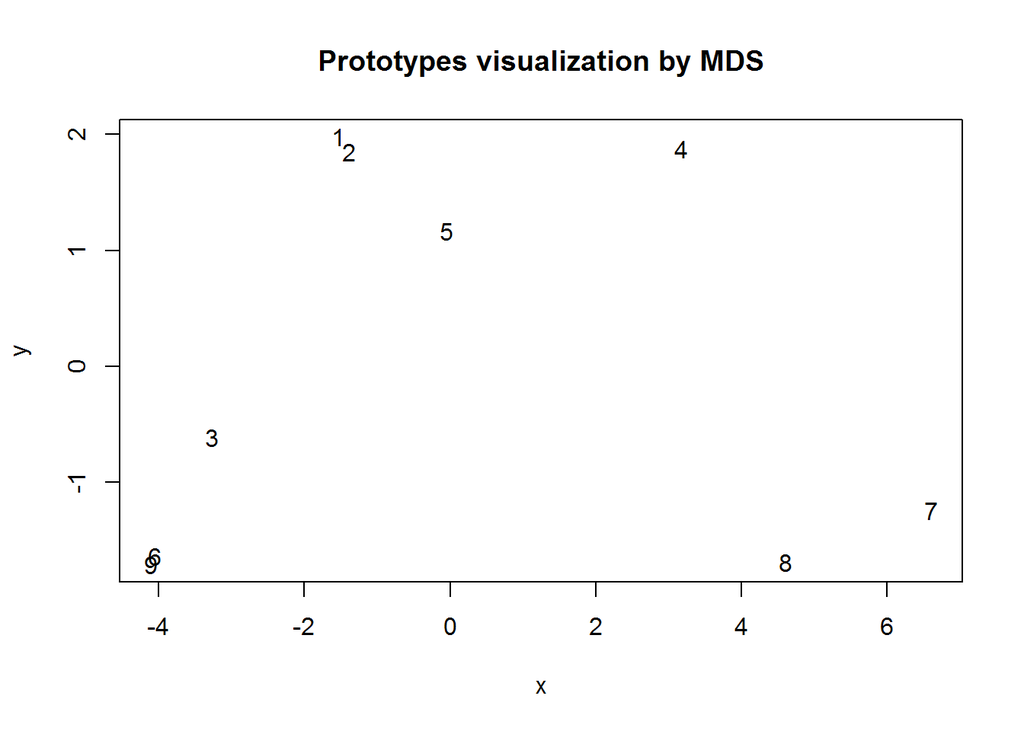

```r
plot(korresp.som, what="prototypes", type="mds")
```

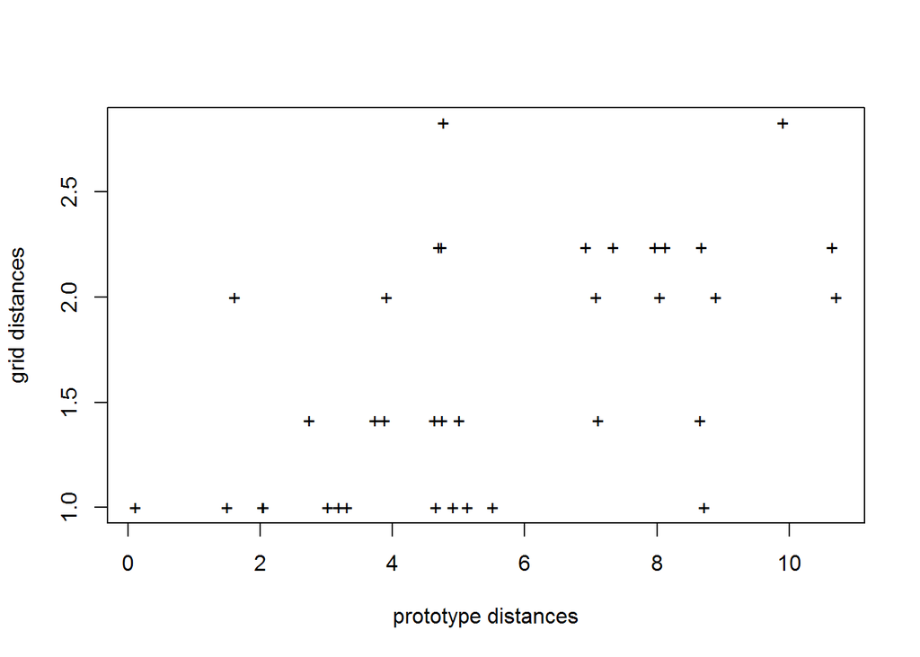

```r
plot(korresp.som, what="prototypes", type="grid.dist")
```

- “poly.dist” represents the distances between neighboring prototypes with polygons plotted for each cell of the grid. The smaller the distance between a polygon’s vertex and a cell border, the closer the pair of prototypes. The colors indicates the number of observations in the neuron (white is used for empty neurons);
- “umatrix” fills the neurons of the grid using colors that represent the average distance between the current prototype and its neighbors;
- “smooth.dist” plots the mean distance between the current prototype and its neighbors with a color gradation;
- mds plots the number of the neuron on a map according to a Multi Dimensional Scaling (MDS) projection;
- grid.dist plots a point for each pair of prototypes, with x coordinates representing the distance between the prototypes in the input space, and y coordinates representing the distance between the corresponding neurons on the grid.

These graphics show that there clusters 1 and 2 are very close together. Hence, for instance, `EyeHazel` and `HairBlack` are stongly associated with each other. This is also emphasized on the MDS plot where clusters 1 and 2 are very close. Simlarly cluster 6 and 9 are adjacent and close together, indicating `HairBrown` & `EyeBrown` are strongly associated.

**Analyze the projection quality**

```r
quality(korresp.som)
```

```
## $topographic
## [1] 0
##
## $quantization
## [1] 1.837401
```

By default, the quality function calculates both quantization and topographic errors. It is also possible to specify which one you want using the argument quality.type.

The topographic error value varies between 0 (good projection quality) and 1 (poor projection quality). Here, the topographic quality of the mapping is 0, which means that all observations have a second best unit which is in the neighborhood of the best matching unit.

The quantization error is an unbounded positive number. The closer it is to 0, the better the projection quality.

**Building super classes from the resulting SOM**

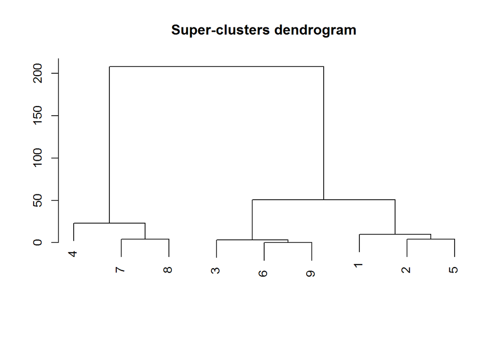

```r
plot(superClass(korresp.som))
```

```r
my.sc <- superClass(korresp.som, k=3)
summary(my.sc)
```

```
##
##    SOM Super Classes
##      Initial number of clusters :  9
##      Number of super clusters   :  3
##
##
##   Frequency table
## 1 2 3
## 3 3 3
##
##   Clustering
## 1 2 3 4 5 6 7 8 9
## 1 1 2 3 1 2 3 3 2
```

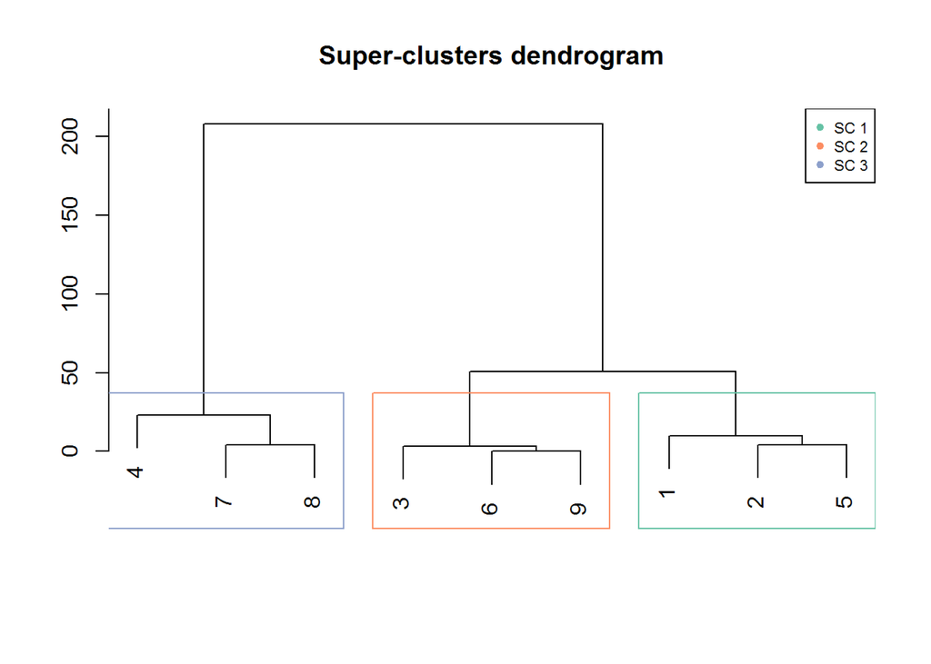

```r
plot(my.sc, plot.var=FALSE)
```

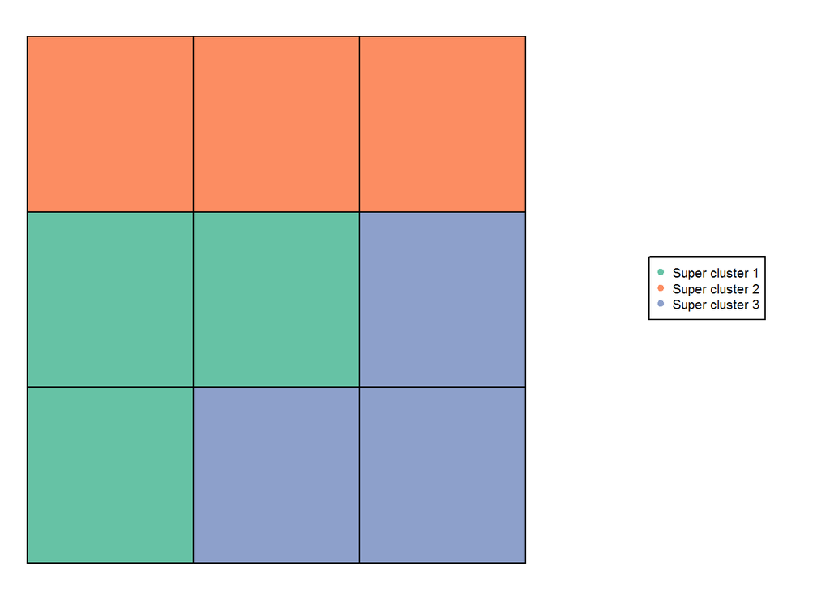

```r
plot(my.sc, type="grid", plot.legend=TRUE)
```

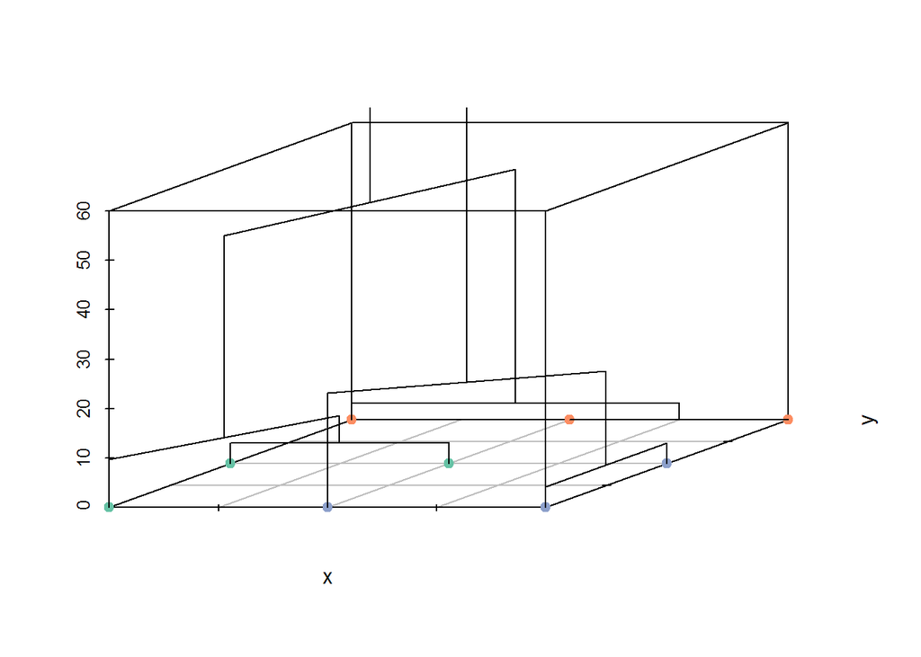

```r
plot(my.sc, type="dendro3d")
```

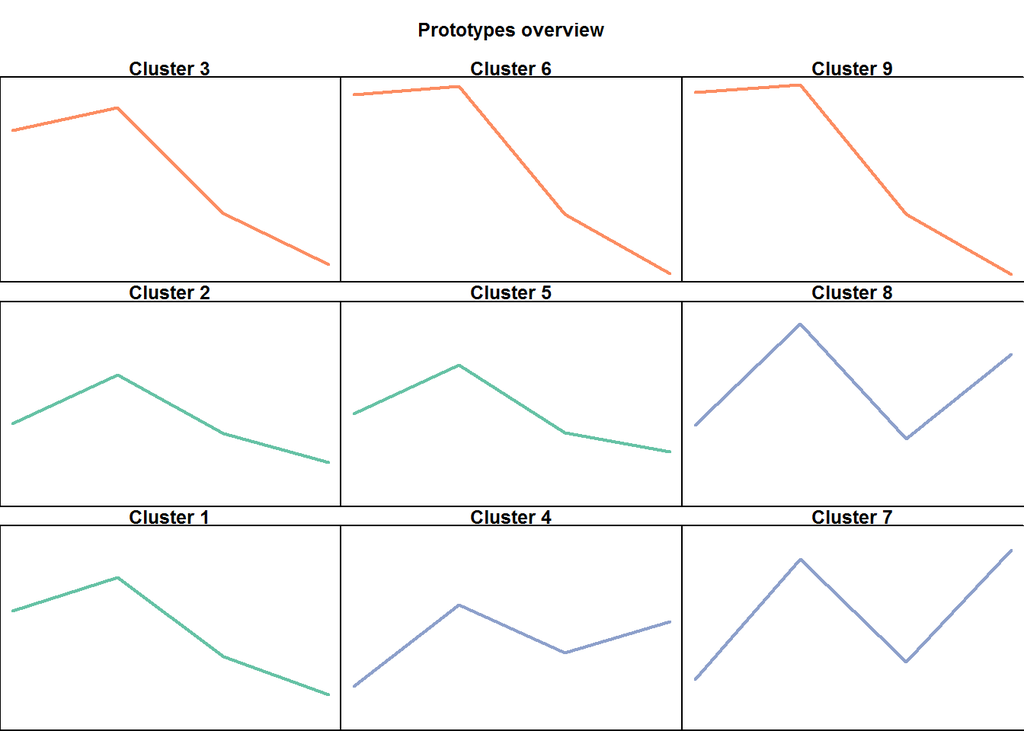

```r
plot(my.sc, type="lines", print.title=TRUE, view="r")
```

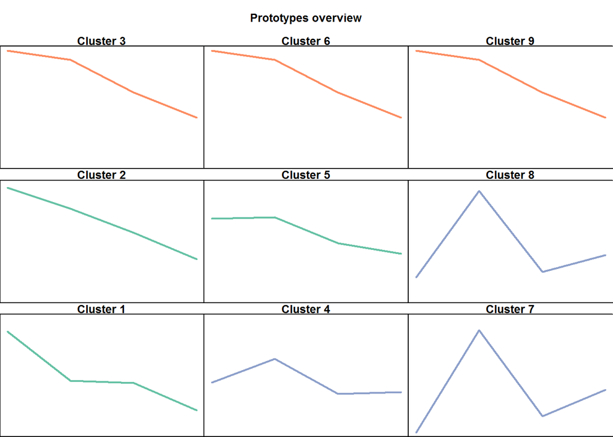

```r
plot(my.sc, type="lines", print.title=TRUE, view="c")
```

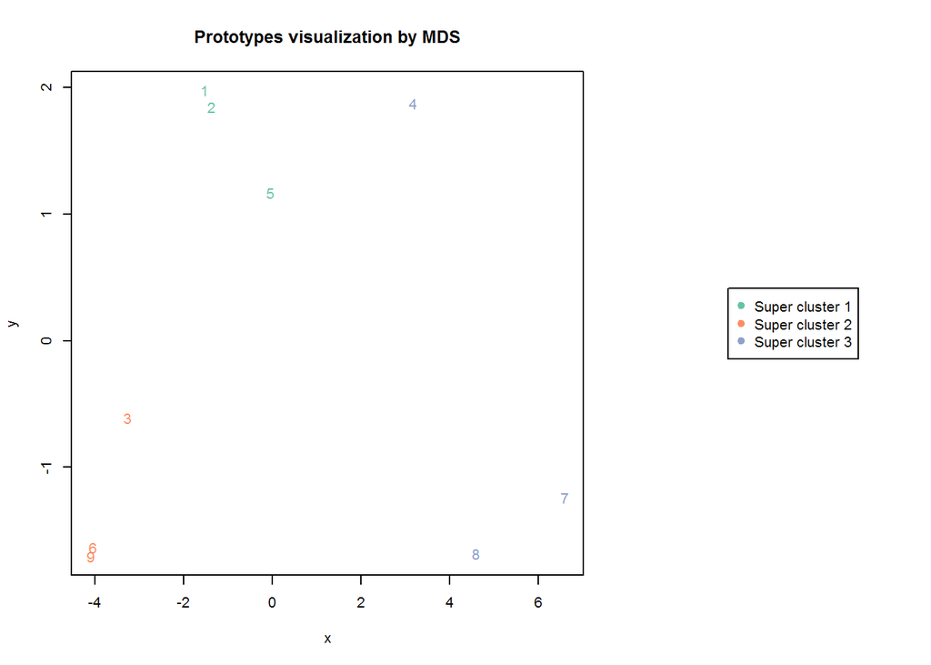

```r
plot(my.sc, type="mds", plot.legend=TRUE)
```

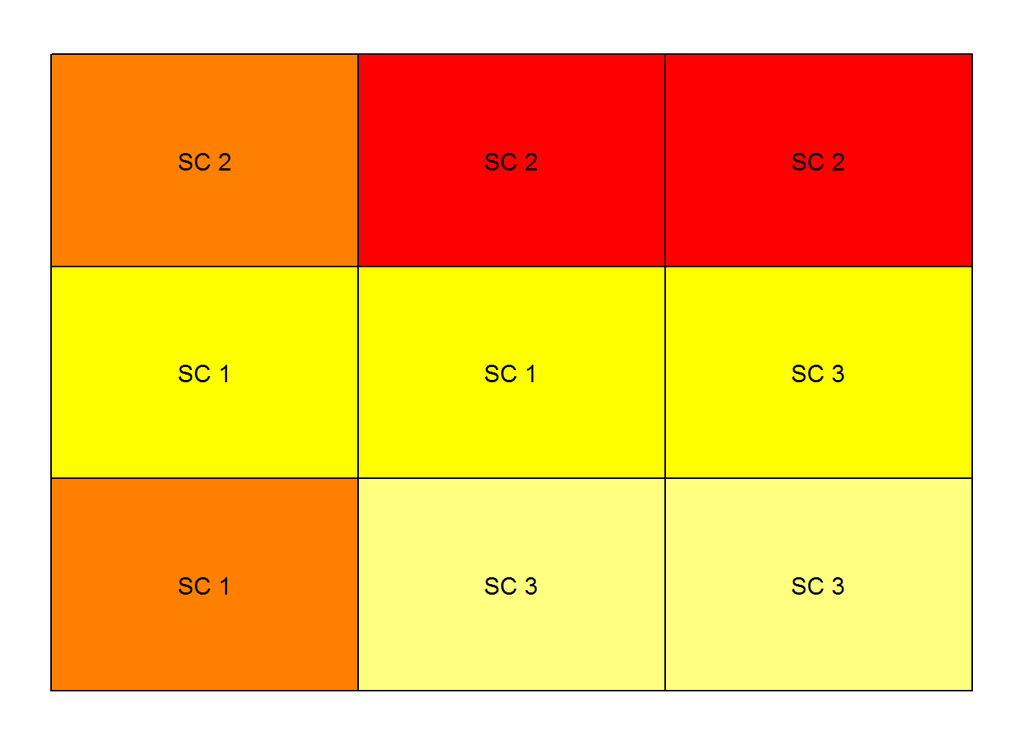

```r
plot(my.sc, type="color", view="r", variable="HairBlack")
```

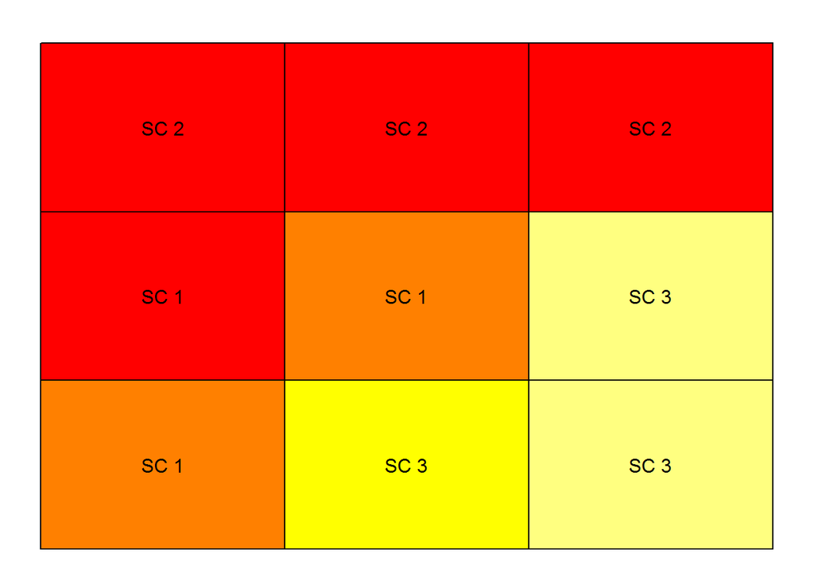

```r
plot(my.sc, type="color", view="c", variable="EyeHazel")
```

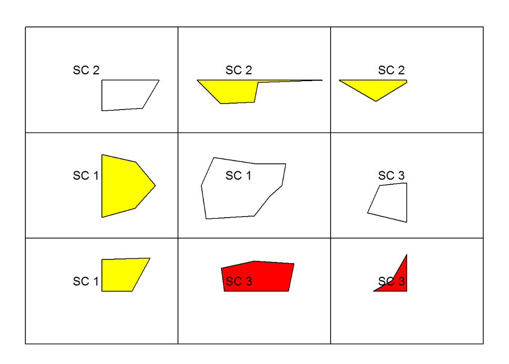

```r
plot(my.sc, type="poly.dist")
```

## initSOM Documentation

Roxygen2 documentation of initSOM.

```r
#' Initialize parameters for the SOM algorithm
#'
#' @description The \code{initSOM} function returns a \code{paramSOM} class object which contains the parameters needed to run the SOM algorithm.
#'
#' @param dimension Vector of two integer points corresponding to the x dimension
#'      and the y dimension of the \code{myGrid} class object. Default values are: \code{(5,5).
#'      Other data-driven defaults are set by function \code{trainSOM}.
#' @param topo The topology to be used to build the grid of the \code{myGrid} class
#'      object. Default value is \code{square}.
#' @param radius.type The neighbourhood type. Default value is \code{"gaussian"},
#'      which corresponds to a Gaussian neighbourhood. The annealing of the neighbourhood
#'      during the training step is similar to the one implemented in \href{https://github.com/fabrice-rossi/yasomi}{yasomi}.
#'      The alternative value corresponds to an piecewise linear neighbourhood as implementated
#'      by Patrick Letremy in his SAS programs.
#' @param dist.type The neighborhood relationship on the grid. When
#'      \code{radius.type} is \code{letremy}, default value is \code{letremy}
#'      which is the original implementation by Patrick Letremy. When
#'      \code{radius.type} is \code{gaussian}, default value is \code{euclidean}. The
#'      other possible values (\code{maximum}, \code{manhattan}, \code{canberra},
#'      \code{binary}, \code{minkowski}) are passed to \code{method} in function
#'      \code{\link[stats]{dist}}. \code{dist.type="letremy"} is not permitted with
#'      \code{radius.type="gaussian"}.
#' @param type The SOM algorithm type. Possible values are: \code{numeric}
#'      (default value), \code{korresp} and \code{relational}.
#' @param mode The SOM algorithm mode. Default value is \code{online}.
#' @param affectation The SOM affectation type. Default value is \code{standard}
#'      which corresponds to a hard affectation. Alternative is \code{heskes} which
#'      corresponds to Heskes's soft affectation.
#' @param maxit The maximum number of iterations to be done during the SOM
#'      algorithm process. Default value is \code{500}. Other data-driven defaults
#'      are set by function \code{trainSOM}.
#' @param nb.save The number of intermediate back-ups to be done during the
#'      algorithm process. Default value is \code{0}.
#' @param verbose The boolean value which activates the verbose mode during the
#'      SOM algorithm process. Default value is \code{FALSE}.
#' @param proto0 The initial prototypes. Default value is \code{NULL}.
#' @param init.proto The method to be used to initialize the prototypes, which
#'      may be \code{random} (randomization), \code{obs} (each prototype is assigned
#'      a random observation) or \code{pca}. In \code{pca} the prototypes are
#'      initialized to the observations closest to a grid along the two first
#'      principal components of the data (\code{numeric} case) or along a
#'      two-dimensional multidimensional scaling (\code{relational} case, equivalent
#'      to a \code{relational} PCA). Default value is \code{random} for the
#'      \code{numeric} and \code{korresp} types, and \code{obs} for the
#'      \code{relational} type. \code{pca} is not available for \code{korresp} SOM.
#' @param scaling The type of data pre-processing. For \code{numeric} SOM,
#'      possibilities are \code{unitvar} (data are centered and scaled; this
#'      is the default value for a \code{numeric} SOM), \code{none} (no
#'      pre-processing), and \code{center} (data are centered but not scaled).
#'      For \code{korresp} SOM, the only available value is \code{chi2}.
#'      For \code{relational} SOM, possibilities are \code{none} (no pre-processing,
#'      default value for \code{relational} SOM) and \code{cosine}. This last one
#'      first turns the dissimilarity into a similarity using the suggestion in
#'      (Lee and Verleysen, 2007). Then, a cosine normalization as described in
#'      (Ben-Hur and Weston, 2010) is applied to the kernel, that is finally turned
#'      back into its induced distance. For further details on this processing, have
#'      a look at the corresponding documentation in the directory "doc" of the
#'      package's installation directory.
#' @param esp0 The scaling value for the stochastic gradient descent step
#'      in the prototypes' update. The scaling value for the stochastic gradient
#'      descent step is equal to
#'      \eqn{\frac{0.3\epsilon_0}{1+0.2t/\textrm{dim}}}{0.3*eps0/(1+0.2*t/dim)} where
#'      \eqn{t}{t} is the current step number and \eqn{\textrm{dim}}{dim} is the grid
#'      dimension (width multiplied by height).
#' @param x,object an object of class \code{paramSOM}.
#' @param \ldots not used
#'
#' @return The \code{initSOM} function returns an object of class \code{paramSOM} which is
#'      a list of the parameters passed to the \code{initSOM} function, plus the default
#'      parameters for the ones not specified by the user.
#'
#' @author Madalina Olteanu \email{madalina.olteanu@univ-paris1.fr}\cr
#'      Nathalie Villa-Vialaneix \email{nathalie.villa-vialaneix@inra.fr}
#'
#' @references Ben-Hur A., Weston J. (2010) A user's guide to support vector machine. In:
#'      \emph{Data Mining Techniques for the Life Sciences}, Springer-Verlag, 223-239.
#'
#'      Heskes T. (1999) Energy functions for self-organizing maps. In: \emph{Kohonen
#'      Maps}, Oja E., Kaski S. (Eds.), Elsevier, 303-315.
#'
#'      Lee J., Verleysen M. (2007) \emph{Nonlinear Dimensionality Reduction}.
#'      Information Science and Statistics series, Springer.
#'
#'      Letremy P. (2005) Programmes bases sur l'algorithme de Kohonen et dedies a
#'      l'analyse des donnees. SAS/IML programs for 'korresp'.
#'      \url{http://samm.univ-paris1.fr/Programmes-SAS-de-cartes-auto}.
#'
#'      Rossi F. (2013) yasomi: Yet Another Self-Organising Map Implementation. R
#'      package, version 0.3. \url{https://github.com/fabrice-rossi/yasomi}
#'
#' @seealso See \link{initGrid} for creating a SOM prior structure (grid).
#'
#' @examples # create a default 'paramSOM' class object
#'      default.paramSOM <- initSOM()
#'      summary(default.paramSOM)
#'
#' @export
initSOM <- function(dimension=c(5,5), topo=c("square"),
                    radius.type=c("gaussian", "letremy"),
                    dist.type=switch(match.arg(radius.type),
                                     "letremy"="letremy",
                                     "gaussian"="euclidean"),
                    type=c("numeric", "relational", "korresp"),
                    mode=c("online"), affectation=c("standard", "heskes"),
                    maxit=500, nb.save=0, verbose=FALSE, proto0=NULL,
                    init.proto=switch(type,
                                      "numeric"="random",
                                      "relational"="obs",
                                      "korresp"="random"),
                    scaling=switch(type,
                                   "numeric"="unitvar",
                                   "relational"="none",
                                   "korresp"="chi2"), eps0=1) {
  type <- match.arg(type)
  radius.type <- match.arg(radius.type)
  affectation <- match.arg(affectation)
  scaling <- match.arg(scaling,
                       c("unitvar", "none", "center", "chi2", "cosine"))
  dist.type <- match.arg(dist.type, c("letremy", "maximum", "euclidean",
                                      "manhattan", "canberra", "binary",
                                      "minkowski"))

  if (dist.type=="letremy" && radius.type=="gaussian") {
    dist.type <- "euclidean"
    warning("dist.type value replaced to 'euclidean' for Gaussian radius\n
            ('letremy' is not allowed)\n",
            call.=TRUE, immediate.=TRUE)
  }

  init.proto <- match.arg(init.proto, c("random", "obs", "pca"))

  # check scaling compatibility
  if (type=="korresp" && scaling!="chi2") {
    scaling <- "chi2"
    warning("scaling value replaced: must be 'chi2' for 'korresp' type\n",
            call.=TRUE, immediate.=TRUE)
  }
  if (type=="relational" && ! scaling %in% c("none", "cosine")) {
    scaling <- "none"
    warning("Wrong scaling for 'relational' SOM ; set to 'none'\n", call.=TRUE,
            immediate.=TRUE)
  }
  if (type=="numeric" && scaling %in% c("chi2", "cosine"))
    stop(paste0("scaling='", scaling,
                "' is only implemented for 'korresp' type\n"), call.=TRUE)

  # check init.proto compatibility
  if (type=="korresp" && init.proto=="pca")
    stop("'init.proto' cannot be 'pca' for 'korresp' type\n", call.= TRUE)

  # check proto0
  if (!is.null(proto0)) {
    if (type=="relational") {
      if (sum(proto0<0)>0)
        stop("initial prototypes given by user do not match chosen type.
             Prototype values must be greater than 0.\n", call.=TRUE)
      if (sum(rowSums(proto0)!=1)>0)
        stop("initial prototypes given by user do not match chosen type.
             Prototype row sums for 'relational' must be equal to 1\n",
             call.=TRUE)
    }
    if (type=="korresp") {
      if (min(proto0)<0 || max(proto0)>1)
        stop("initial prototypes given by user do not match chosen type.
             Prototypes for 'korresp' must have values between 0 and 1\n",
             call.=TRUE)
    }
  }

  params <- list("the.grid"=initGrid(dimension,match.arg(topo),
                                     dist.type),
                 type=type, mode=match.arg(mode), affectation=affectation,
                 maxit=maxit, nb.save=nb.save, proto0=proto0,
                 init.proto=init.proto, scaling=scaling,
                 radius.type=radius.type, verbose=verbose, eps0=eps0)

  class(params) <- "paramSOM"

  return(params)
}
```

## initSOM Tests

Unit tests with testthat for the function `initSOM`.

Following is the content of file ‘test-initSOM.r’.

```r
library(testthat)
context("Check the initSOM function for correct initialization")

test_that("checking errors are thrown for incompatible initial prototypes", {
  expect_error(initSOM(dimension = c(5,5), proto0 = matrix(c(-1,1), nrow=1), type="relational" ));
  expect_error(initSOM(dimension = c(5,5), proto0 = matrix(c(1,1), nrow = 1), type="relational" ));
  expect_error(initSOM(dimension = c(5,5), proto0 = matrix(c(2), nrow=1), type="korresp" ));
  expect_error(initSOM(dimension = c(5,5), proto0 = matrix(c(-1), nrow=1), type="korresp" ));
})

test_that("checking errors/warnings are thrown for incompatible scaling", {
  expect_warning(initSOM(type="korresp" , scaling="none" ));
  expect_warning(initSOM(type="relational" , scaling="chi2" ));
  expect_error(initSOM(type="numeric" , scaling="chi2" ));
})

test_that("checking errors are thrown with incompatible init.proto", {
  expect_error(initSOM(type="korresp" , init.proto = "pca" ));
})
```

## ggplot2 plots

Modified plot functions in ‘SOMBrero’ using ggplot2. Can be used for `plot(..., what="obs", type="hitmap")` & `plot(..., what="prototypes", type="color", var=1)`

```r
library(ggplot2)
```

```r
plotPrototypes <- function(sommap, type, variable, my.palette, print.title,
                           the.titles, is.scaled, view, args) {

  # default value for type="lines"
  if (!is.element(type,c("color"))) {
    warning("incorrect type replaced by 'color'\n", call.=TRUE,
            immediate.=TRUE)
    type <- "color"
  }
  # relational control
  if (sommap$parameters$type=="relational" && type %in% c("color"))
    stop("prototypes/", type, " plot is not available for 'relational'\n",
         call.=TRUE)

  if (type=="color") {
    if (length(variable)>1) {
      warning("length(variable)>1, only first element will be considered\n",
              call.=TRUE, immediate.=TRUE)
      variable <- variable[1]
    }

    if (sommap$parameters$type=="korresp" & (is.numeric(variable))) {
      if (view=="r")
        tmp.var <- variable+ncol(sommap$data)
      else tmp.var <- variable
    } else tmp.var <- variable

    the.grid = sommap$parameters$the.grid
    values <- sommap$prototypes[,tmp.var]
    x <- values

    if (is.null(my.palette)) {
      nb.breaks <- min(c(floor(1 + (3.3*log(prod(the.grid$dim),base=10))),
                         9))
    } else nb.breaks <- length(my.palette)
    the.breaks <- seq(min(x, na.rm=TRUE)-10^(-5),
                      max(x, na.rm=TRUE)+10^(-5),
                      length=nb.breaks+1)
    if (is.null(my.palette)) {
      my.colors <- heat.colors(nb.breaks)[nb.breaks:1]
    } else my.colors <- my.palette
    vect.color <- my.colors[cut(x, the.breaks, labels=FALSE)]

    plot <- ggplot() + theme(axis.line=element_blank(),
                             axis.text.x=element_blank(),
                             axis.text.y=element_blank(),
                             axis.ticks=element_blank(),
                             axis.title.x=element_blank(),
                             axis.title.y=element_blank(),
                             legend.position="none",
                             panel.background=element_blank(),
                             panel.border=element_blank(),
                             panel.grid.major=element_blank(),
                             panel.grid.minor=element_blank(),
                             plot.background=element_blank())

    gridbasesize <- 0.5
    data <- data.frame(xleft=(the.grid$coord[,1]-gridbasesize),
                       xright=(the.grid$coord[,1]+gridbasesize),
                       ybottom=(the.grid$coord[,2]-gridbasesize),
                       ytop=(the.grid$coord[,2]+gridbasesize),
                       density=cut(x, the.breaks, labels=FALSE))

    plot <- plot +
      geom_rect( data, mapping=aes(xmin=xleft, xmax=xright, ymin=ybottom, ymax=ytop, fill=factor(density)), color="black" ) +
      scale_fill_manual(values = my.colors)

    if (print.title) {
      plot <- plot +
        geom_text( aes(x = the.grid$coord[,1], y = the.grid$coord[,2], label = the.titles, cex = 0.7) )
    }

    plot

  }

}



plothitmap <- function(sommap, type, my.palette, print.title, the.titles,
                    is.scaled, view, args) {

  # default value is type="hitmap"
  if (!is.element(type,c("hitmap"))) {
    warning("incorrect type replaced by 'hitmap'\n", call.=TRUE,
            immediate.=TRUE)
    type <- "hitmap"
  }
  # korresp control
  if (sommap$parameters$type=="korresp" && !(type%in%c("hitmap"))) {
    warning("korresp SOM: incorrect type replaced by 'hitmap'\n", call.=TRUE,
            immediate.=TRUE)
    type <- "hitmap"
  }
  # relational control
  if (sommap$parameters$type=="relational" && !(type%in%c("hitmap"))) {
    warning("relational SOM: incorrect type replaced by 'hitmap'\n",
            call.=TRUE, immediate.=TRUE)
    type <- "hitmap"
  }

  if (type=="hitmap") {
    freq <- sapply(1:nrow(sommap$prototypes), function(ind) {
      length(which(sommap$clustering==ind))
    })
    freq <- freq/sum(freq)
    # basesize is 0.45 for the maximum frequence
    basesize <- 0.45*sqrt(freq)/max(sqrt(freq))

    if (is.null(args$col)) {
      my.colors <- rep("pink", nrow(sommap$prototypes))
    } else if (length(args$col)==1) {
      my.colors <- rep(args$col, nrow(sommap$prototypes))
    } else {
      if(length(args$col)==nrow(sommap$prototypes)){
        my.colors <- args$col
      } else {
        warning("unadequate number of colors default color will be used\n",
                immediate.=TRUE, call.=TRUE)
        my.colors <- rep("pink", nrow(sommap$prototypes))
      }
    }

    plot <- ggplot() + theme(axis.line=element_blank(),
                             axis.text.x=element_blank(),
                             axis.text.y=element_blank(),
                             axis.ticks=element_blank(),
                             axis.title.x=element_blank(),
                             axis.title.y=element_blank(),
                             legend.position="none",
                             panel.background=element_blank(),
                             panel.border=element_blank(),
                             panel.grid.major=element_blank(),
                             panel.grid.minor=element_blank(),
                             plot.background=element_blank())

    x=sommap$parameters$the.grid

    gridbasesize <- 0.5
    data <- data.frame(xleft=(x$coord[,1]-gridbasesize),
                       xright=(x$coord[,1]+gridbasesize),
                       ybottom=(x$coord[,2]-gridbasesize),
                       ytop=(x$coord[,2]+gridbasesize))

    rects <- data.frame(xleft = (sommap$parameters$the.grid$coord[,1]-basesize),
                        xright = (sommap$parameters$the.grid$coord[,1]+basesize),
                        ybottom = (sommap$parameters$the.grid$coord[,2]-basesize),
                        ytop = (sommap$parameters$the.grid$coord[,2]+basesize),
                        my.colors=my.colors)


    plot <- plot +
      geom_rect( data, mapping=aes(xmin=xleft, xmax=xright, ymin=ybottom, ymax=ytop),fill="white", color="black", alpha=1) +
      geom_rect(data=rects, mapping=aes(xmin=xleft, xmax=xright, ymin=ytop, ymax=ybottom, fill=factor(1:nrow(sommap$prototypes)) ))+
      scale_fill_manual(values = my.colors)

    the.grid <- sommap$parameters$the.grid
    if (print.title) {
      plot <- plot +
        geom_text( aes(x = the.grid$coord[,1], y = the.grid$coord[,2], label = the.titles, cex = 0.7) )
    }

    plot

  }
}



plotFunc <- function(x, what=c("obs", "prototypes"),
                        type=switch(what,
                                    "obs"="hitmap",
                                    "prototypes"="color"),
                        variable = if (type=="boxplot") 1:min(5,ncol(x$data)) else 1,
                        my.palette=NULL,
                        is.scaled = if (x$parameters$type=="numeric") TRUE else
                          FALSE,
                        print.title=FALSE, the.titles=
                          switch(type,
                                 "graph"=1:prod(x$parameters$the.grid$dim),
                                 paste("Cluster",
                                       1:prod(x$parameters$the.grid$dim))),
                        proportional=TRUE,
                        view = if (x$parameters$type=="korresp") "r" else NULL,
                        ...) {
  args <- list(...)
  what <- match.arg(what)
  if ((x$parameters$type=="korresp")&&!(view%in%c("r","c")))
    stop("view must be one of 'r'/'c'",call.=TRUE)
  if (length(the.titles)!=prod(x$parameters$the.grid$dim) & what!="energy") {
    the.titles=switch(type,
                      "graph"=1:prod(x$parameters$the.grid$dim),
                      paste("Cluster",1:prod(x$parameters$the.grid$dim)))
    warning("unadequate length for 'the.titles'; replaced by default",
            call.=TRUE, immediate.=TRUE)
  }

  switch(what,
         "prototypes"=plotPrototypes(x, type, variable, my.palette, print.title,
                                     the.titles, is.scaled, view, args),
         "obs"=plothitmap(x, type, my.palette, print.title, the.titles,
                       is.scaled, view, args))
}
```

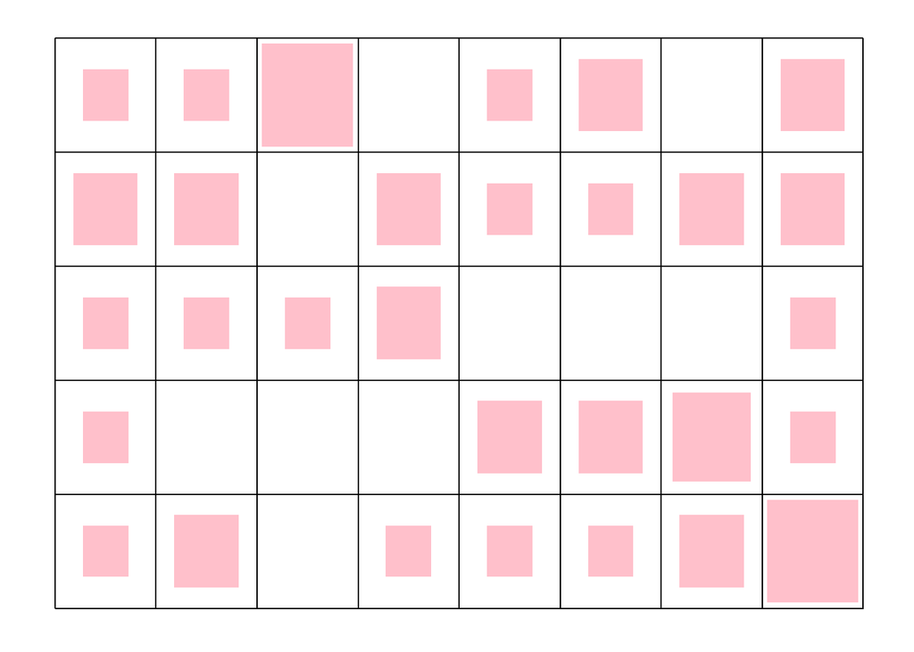

```r
plotFunc(my.som, what="obs", type="hitmap")
```

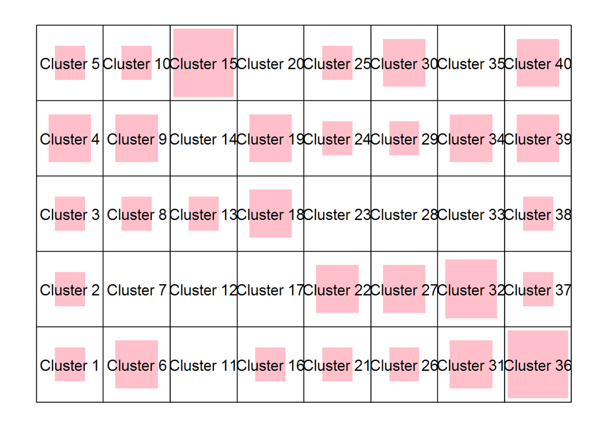

```r
plotFunc(my.som, what="obs", type="hitmap", col = rainbow(25), print.title = TRUE )
```

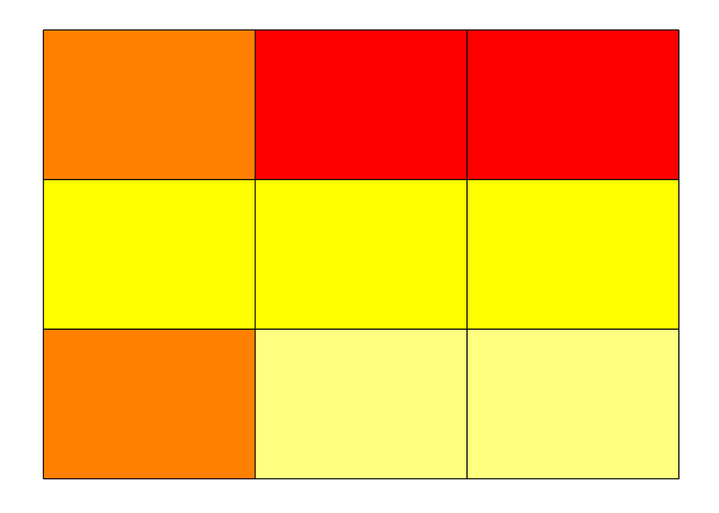

```r
plotFunc(korresp.som, what="prototypes", type="color", var=1 )
```

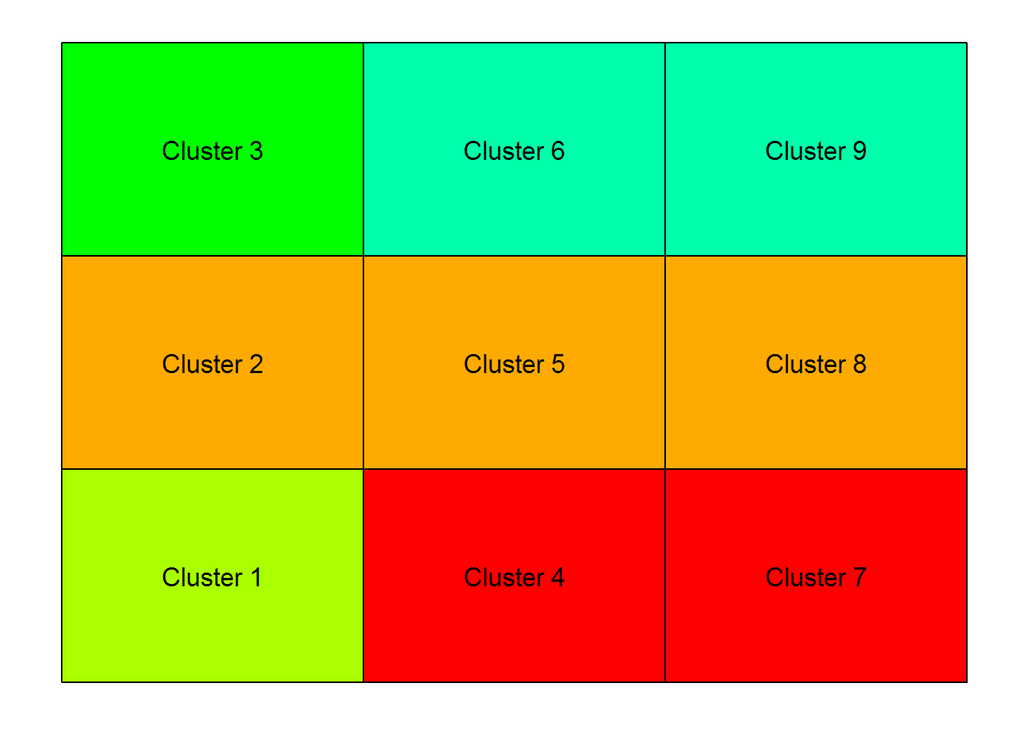

```r
plotFunc(korresp.som, what="prototypes", type="color", var=1 , my.palette = rainbow(9), print.title = TRUE )
```

## Rcpp predict

Re-wrote the current predict function for the case “numerical” with C++ computation and Rcpp & then analysed the performance gains using microbenchmark.

```r
library(Rcpp)
```

```cpp
#include <Rcpp.h>
#include <limits>
using namespace Rcpp;

// [[Rcpp::export]]
IntegerVector cppobsAffection(NumericMatrix x_new, NumericMatrix prototypes) {
    int n_obs = x_new.rows();
    int n_proto = prototypes.rows();
    int dim_proto = prototypes.cols();
    IntegerVector winners(n_obs);

    for(int obs=0; obs<n_obs; obs++) {
        int current_min=1;
        double min_dist=std::numeric_limits<double>::max();
        for(int proto=0; proto<n_proto; proto++){
            double dist_sum=0.0;
            for(int dim=0; dim<dim_proto; dim++){
                dist_sum += pow(prototypes(proto,dim)-x_new(obs,dim), 2);
            }
            if(dist_sum<min_dist){
                current_min = proto+1;
                min_dist = dist_sum;
            }
        }
        winners[obs] = current_min;
    }
    winners.attr("names") = rownames(x_new);
    return winners;
}
```

```r
preprocessProto <- function(prototypes, scaling, x.data) {
  switch(scaling,
         "unitvar"=scale(prototypes,
                         center=apply(x.data,2,mean),
                         scale=apply(x.data,2,sd)),
         "center"=scale(prototypes,
                        center=apply(x.data,2,mean),
                        scale=FALSE),
         "none"=prototypes,
         "chi2"=prototypes,
         "cosine"=prototypes)
}



predictCpp <- function(object, x.new=NULL, ..., radius=0, tolerance=10^(-10)) {
  if (is.null(x.new)) {
    x.new <- object$data
  } else {
    if (is.null(dim(x.new)))
      x.new <- matrix(x.new, nrow=1, dimnames=list(1,colnames(object$data)))
    if (!is.matrix(x.new)) x.new <- as.matrix(x.new)
    # check data dimension
    if (ncol(x.new)!=ncol(object$data))
      stop("Number of columns of x.new does not correspond to number of
             columns of the original data")
  }
  norm.x.new <- switch(object$parameters$scaling,
                       "unitvar"=scale(x.new,
                                       center=apply(object$data,2,mean),
                                       scale=apply(object$data,2,sd)),
                       "center"=scale(x.new,
                                      center=apply(object$data,2,mean),
                                      scale=FALSE),
                       "none"=x.new)
  norm.proto <- preprocessProto(object$prototypes, object$parameters$scaling,
                                object$data)

  winners <- cppobsAffection(norm.x.new, prototypes=norm.proto)

  winners
}
```

```r
predictCpp(my.som)
```

```
##        Alabama         Alaska        Arizona       Arkansas     California
##              6              8              9             18             10
##       Colorado    Connecticut       Delaware        Florida        Georgia
##             19             39              6              5             13
##         Hawaii          Idaho       Illinois        Indiana           Iowa
##             36             26             15             34             36
##         Kansas       Kentucky      Louisiana          Maine       Maryland
##             34             27              1             32              4
##  Massachusetts       Michigan      Minnesota    Mississippi       Missouri
##             30             15             37              2             24
##        Montana       Nebraska         Nevada  New Hampshire     New Jersey
##             27             38             15             36             30
##     New Mexico       New York North Carolina   North Dakota           Ohio
##              9             15              4             31             40
##       Oklahoma         Oregon   Pennsylvania   Rhode Island South Carolina
##             21             22             39             25              3
##   South Dakota      Tennessee          Texas           Utah        Vermont
##             32             18             19             40             31
##       Virginia     Washington  West Virginia      Wisconsin        Wyoming
##             22             29             32             36             16
```

```r
library(microbenchmark)
microbenchmark(predict(my.som), predictCpp(my.som))
```

```
## Unit: microseconds
##                expr     min       lq      mean   median       uq      max
##     predict(my.som) 336.333 356.2685 445.40043 386.4670 427.9170 2771.980
##  predictCpp(my.som)  21.318  23.6860  83.68911  29.2125  33.3575 5199.337
##  neval
##    100
##    100
```

Thus we can see significant improvements in performance of the `predictCpp` function over the existing `predict` function written purely in R.